# Introduction to Principal Component Analysis (PCA) and Partial Least Squares (PLS)

Sameh MAGDELDIN,M.V.Sc, 2 Ph.D

Feb 8, 2025

# Principal Component Analysis (PCA) and Partial Least Squares (PLS)

> Multicollinearity, a frequent challenge in machine learning, arises when predictor variables within a dataset exhibit strong correlations. This can lead to overfitting, where a model performs well on training data but poorly on unseen data.

## Multicollinearity Test

### 1. Load the packages and data

```r
library(car)  # For VIF calculations
```

```r
library(corrplot) # For the correlation matrix visualization
data(USJudgeRatings) # Load the USJudgeRatings data (it's built into R)
head(USJudgeRatings)
```

```
##                CONT INTG DMNR DILG CFMG DECI PREP FAMI ORAL WRIT PHYS RTEN
## AARONSON,L.H.   5.7  7.9  7.7  7.3  7.1  7.4  7.1  7.1  7.1  7.0  8.3  7.8
## ALEXANDER,J.M.  6.8  8.9  8.8  8.5  7.8  8.1  8.0  8.0  7.8  7.9  8.5  8.7
## ARMENTANO,A.J.  7.2  8.1  7.8  7.8  7.5  7.6  7.5  7.5  7.3  7.4  7.9  7.8
## BERDON,R.I.     6.8  8.8  8.5  8.8  8.3  8.5  8.7  8.7  8.4  8.5  8.8  8.7
## BRACKEN,J.J.    7.3  6.4  4.3  6.5  6.0  6.2  5.7  5.7  5.1  5.3  5.5  4.8
## BURNS,E.B.      6.2  8.8  8.7  8.5  7.9  8.0  8.1  8.0  8.0  8.0  8.6  8.6
```

```r
str(USJudgeRatings)
```

```
## 'data.frame':    43 obs. of  12 variables:
##  $ CONT: num  5.7 6.8 7.2 6.8 7.3 6.2 10.6 7 7.3 8.2 ...
##  $ INTG: num  7.9 8.9 8.1 8.8 6.4 8.8 9 5.9 8.9 7.9 ...
##  $ DMNR: num  7.7 8.8 7.8 8.5 4.3 8.7 8.9 4.9 8.9 6.7 ...
##  $ DILG: num  7.3 8.5 7.8 8.8 6.5 8.5 8.7 5.1 8.7 8.1 ...
##  $ CFMG: num  7.1 7.8 7.5 8.3 6 7.9 8.5 5.4 8.6 7.9 ...
##  $ DECI: num  7.4 8.1 7.6 8.5 6.2 8 8.5 5.9 8.5 8 ...
##  $ PREP: num  7.1 8 7.5 8.7 5.7 8.1 8.5 4.8 8.4 7.9 ...
##  $ FAMI: num  7.1 8 7.5 8.7 5.7 8 8.5 5.1 8.4 8.1 ...
##  $ ORAL: num  7.1 7.8 7.3 8.4 5.1 8 8.6 4.7 8.4 7.7 ...
##  $ WRIT: num  7 7.9 7.4 8.5 5.3 8 8.4 4.9 8.5 7.8 ...
##  $ PHYS: num  8.3 8.5 7.9 8.8 5.5 8.6 9.1 6.8 8.8 8.5 ...
##  $ RTEN: num  7.8 8.7 7.8 8.7 4.8 8.6 9 5 8.8 7.9 ...
```

#### a. Data description

```
CONT (Number of Contacts of Lawyer with Judge): عدد مرات الاتصال بين المحامي والقاضي
INTG (Integrity): نزاهة
DMNR (Demeanor): سلوك
DILG (Diligence): اجتهاد
CFMG (Case Flow Management): إدارة سير الدعاوى
DECI (Decisiveness): حسم
PREP (Preparedness): استعداد
FAMI (Familiarity with Law): إلمام بالقانون
ORAL (Oral Arguments): المرافعات الشفهية
WRIT (Written Opinions): الأحكام المكتوبة
PHYS (Physical Facilities): المرافق المادية
RTEN (Retention Recommendation): توصية بالإبقاء
```

### 2. Test multicolinearity

#### a. Calculate correlation matrix

> Look at the correlation matrix. Almost all variables are highly correlated (close to 1). This is a strong indication of multicollinearity.

```r
cor_matrix <- cor(USJudgeRatings)
print("Correlation Matrix:")
```

```
## [1] "Correlation Matrix:"
```

```r
print(round(cor_matrix, 2))
```

```
##       CONT  INTG  DMNR DILG CFMG DECI PREP  FAMI  ORAL  WRIT PHYS  RTEN
## CONT  1.00 -0.13 -0.15 0.01 0.14 0.09 0.01 -0.03 -0.01 -0.04 0.05 -0.03
## INTG -0.13  1.00  0.96 0.87 0.81 0.80 0.88  0.87  0.91  0.91 0.74  0.94
## DMNR -0.15  0.96  1.00 0.84 0.81 0.80 0.86  0.84  0.91  0.89 0.79  0.94
## DILG  0.01  0.87  0.84 1.00 0.96 0.96 0.98  0.96  0.95  0.96 0.81  0.93
## CFMG  0.14  0.81  0.81 0.96 1.00 0.98 0.96  0.94  0.95  0.94 0.88  0.93
## DECI  0.09  0.80  0.80 0.96 0.98 1.00 0.96  0.94  0.95  0.95 0.87  0.92
## PREP  0.01  0.88  0.86 0.98 0.96 0.96 1.00  0.99  0.98  0.99 0.85  0.95
## FAMI -0.03  0.87  0.84 0.96 0.94 0.94 0.99  1.00  0.98  0.99 0.84  0.94
## ORAL -0.01  0.91  0.91 0.95 0.95 0.95 0.98  0.98  1.00  0.99 0.89  0.98
## WRIT -0.04  0.91  0.89 0.96 0.94 0.95 0.99  0.99  0.99  1.00 0.86  0.97
## PHYS  0.05  0.74  0.79 0.81 0.88 0.87 0.85  0.84  0.89  0.86 1.00  0.91
## RTEN -0.03  0.94  0.94 0.93 0.93 0.92 0.95  0.94  0.98  0.97 0.91  1.00
```

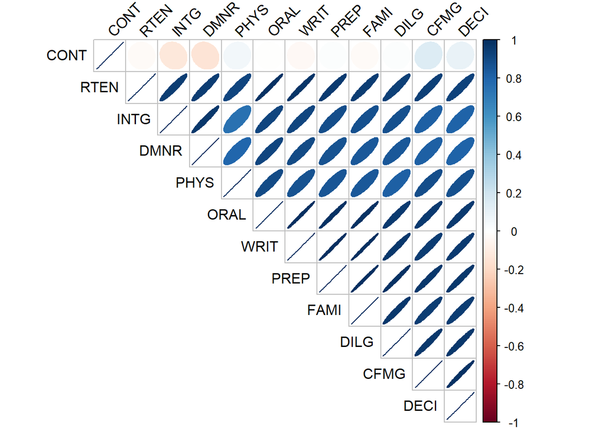

```r
corrplot::corrplot(round(cor_matrix, 2), method = "ellipse", type = "upper", order = "hclust", tl.col = "black", tl.srt = 45) # tl.srt rotates text labels
```

#### b. Variance Inflation Factors (VIF)

> The VIF values will likely be very high (probably above 10, often much higher). This confirms the multicollinearity.

```r
# Fit a linear model (even though you might not primarily be doing linear regression,
# VIFs are still a useful diagnostic for multicollinearity among the predictors)
model <- lm(INTG ~ ., data = USJudgeRatings)  #INTG can be any variable.
vif_values <- vif(model)
print("Variance Inflation Factors (VIFs):")
```

```
## [1] "Variance Inflation Factors (VIFs):"
```

```r
print(vif_values)
```

```
##       CONT       DMNR       DILG       CFMG       DECI       PREP       FAMI
##   1.774823  25.760590  42.805043  51.971226  35.336718 152.388366 195.352413
##       ORAL       WRIT       PHYS       RTEN
## 267.260283 275.761564  13.952322  94.788953
```

#### c. Tolerance (just 1/VIF)

> Tolerance values will be very low (close to 0).

```r
tolerance <- 1/vif(model)
print("Tolerance:")
```

```
## [1] "Tolerance:"
```

```r
print(tolerance)
```

```
##        CONT        DMNR        DILG        CFMG        DECI        PREP
## 0.563436347 0.038818986 0.023361733 0.019241416 0.028299176 0.006562181
##        FAMI        ORAL        WRIT        PHYS        RTEN
## 0.005118954 0.003741671 0.003626321 0.071672660 0.010549753
```

> What to do? Given the extremely high multicollinearity, techniques like Principal Component Analysis (PCA) or Partial Least Squares (PLS) are highly recommended for this dataset. Regular linear regression would be very problematic due to the unstable coefficient estimates.

## Principal Component Analysis (PCA)

> Method of multivariate analysis

> Principal component analysis (PCA) is a technique used to emphasize variation and bring out strong patterns in a dataset. It’s often used to make data easy to explore and visualize.

> If you have 20 variable,how do you understand the interrelaionship? there are 190 pairwise correlation. even though, still difficult!

> It is a dimensionality reduction technique that is widely used in data analysis [visualized data is limited to 2 or 3 dimensions].

> So, **PCA is a data reduction technique that transforms a larger number of correlated variables into a much smaller set of uncorrelated variables called principal components**

#### The main goals of principal component analysis is:

> 1.to identify hidden pattern in a data set.

> 2.to reduce the dimensionnality of the data by removing the noise and redundancy in the data.

> 3.to identify correlated variables.

#### Example you might use PCA to transform 30 correlated (or possibly redundant) variables into 5 uncorrelated variables (principal companants) that retains as much information from the original set.

### Required packeges

```r
library(psych)
library(RColorBrewer)
```

### 1. Selecting the number of components to extract

#### We need to know how many components to be extracted, the most common approach is based on something called **eigenvalues** . each component is associated with eigenvalue. the 1st PC is associated with the largest eigenvalue, the 2nd PC is associated with the 2nd largest value and so on.

#### We will retain components with eigenvalues equal or more than 1 [role of thumb]

#### R can do this for you, i will use fa.parallel function in psych package

#### Perform parallel analysis to determine the number of components/factors

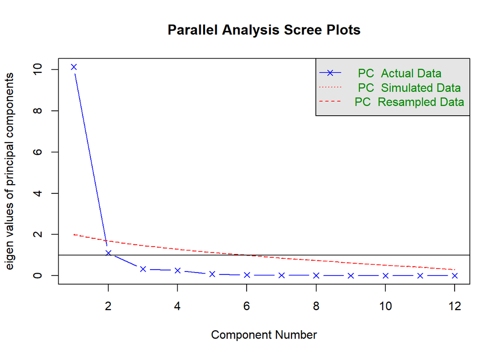

```
## Parallel analysis suggests that the number of factors =  NA  and the number of components =  1
```

```r
fa.parallel(USJudgeRatings, n.iter = 100, fa = "pc") # fa = "pc" for PCA
```

### 2. Extracting principal component

#### Using principal() function, we will extract the PC.

#### Perform Principal Component Analysis (PCA) - based on parallel analysis results (1 component suggested)

```r
pca_result <- principal(USJudgeRatings, nfactors = 1, rotate = "none") # rotate = "none" for PCA
# Summarize the PCA results
print(pca_result)
```

```
## Principal Components Analysis
## Call: principal(r = USJudgeRatings, nfactors = 1, rotate = "none")
## Standardized loadings (pattern matrix) based upon correlation matrix
##        PC1      h2     u2 com
## CONT -0.01 9.6e-05 0.9999   1
## INTG  0.92 8.4e-01 0.1563   1
## DMNR  0.91 8.3e-01 0.1660   1
## DILG  0.97 9.4e-01 0.0613   1
## CFMG  0.96 9.3e-01 0.0723   1
## DECI  0.96 9.2e-01 0.0764   1
## PREP  0.98 9.7e-01 0.0299   1
## FAMI  0.98 9.5e-01 0.0469   1
## ORAL  1.00 9.9e-01 0.0091   1
## WRIT  0.99 9.8e-01 0.0195   1
## PHYS  0.89 8.0e-01 0.2014   1
## RTEN  0.99 9.7e-01 0.0275   1
##
##                  PC1
## SS loadings    10.13
## Proportion Var  0.84
##
## Mean item complexity =  1
## Test of the hypothesis that 1 component is sufficient.
##
## The root mean square of the residuals (RMSR) is  0.05
##  with the empirical chi square  12.56  with prob <  1
##
## Fit based upon off diagonal values = 1
```

#### Explore the PCA output in more detail

```r
pca_result$values # Eigenvalues
```

```
##  [1] 10.133503726  1.104146980  0.332901600  0.253847001  0.084452786
##  [6]  0.037286058  0.019682813  0.015415288  0.007833472  0.005611727
## [11]  0.003258175  0.002060374
```

```r
pca_result$loadings # Component loadings (pattern matrix)
```

```
##
## Loadings:
##      PC1
## CONT
## INTG  0.919
## DMNR  0.913
## DILG  0.969
## CFMG  0.963
## DECI  0.961
## PREP  0.985
## FAMI  0.976
## ORAL  0.995
## WRIT  0.990
## PHYS  0.894
## RTEN  0.986
##
##                   PC1
## SS loadings    10.134
## Proportion Var  0.844
```

```r
pca_result$communality # Communalities (h2)
```

```
##         CONT         INTG         DMNR         DILG         CFMG         DECI
## 9.582754e-05 8.437312e-01 8.340132e-01 9.386808e-01 9.277249e-01 9.235550e-01
##         PREP         FAMI         ORAL         WRIT         PHYS         RTEN
## 9.701041e-01 9.530797e-01 9.909200e-01 9.805086e-01 7.985784e-01 9.725121e-01
```

```r
pca_result$uniquenesses # Uniquenesses (u2)
```

```
##        CONT        INTG        DMNR        DILG        CFMG        DECI
## 0.999904172 0.156268774 0.165986825 0.061319233 0.072275112 0.076445029
##        PREP        FAMI        ORAL        WRIT        PHYS        RTEN
## 0.029895884 0.046920343 0.009080029 0.019491406 0.201421606 0.027487860
```

#### If parallel analysis suggested more components (e.g., 2), you would change nfactors:

```r
pca_result_2 <- principal(USJudgeRatings, nfactors = 2, rotate = "varimax") # Example with 2 components and varimax rotation
# Summarize the PCA results
print(pca_result_2)
```

```
## Principal Components Analysis
## Call: principal(r = USJudgeRatings, nfactors = 2, rotate = "varimax")
## Standardized loadings (pattern matrix) based upon correlation matrix
##       RC1   RC2   h2     u2 com
## CONT 0.00  0.98 0.96 0.0390 1.0
## INTG 0.92 -0.20 0.88 0.1197 1.1
## DMNR 0.91 -0.22 0.88 0.1229 1.1
## DILG 0.97  0.03 0.94 0.0599 1.0
## CFMG 0.97  0.17 0.96 0.0410 1.1
## DECI 0.96  0.12 0.94 0.0584 1.0
## PREP 0.99  0.02 0.97 0.0287 1.0
## FAMI 0.98 -0.01 0.95 0.0469 1.0
## ORAL 1.00 -0.01 0.99 0.0091 1.0
## WRIT 0.99 -0.04 0.98 0.0184 1.0
## PHYS 0.89  0.08 0.81 0.1927 1.0
## RTEN 0.99 -0.05 0.97 0.0258 1.0
##
##                         RC1  RC2
## SS loadings           10.13 1.11
## Proportion Var         0.84 0.09
## Cumulative Var         0.84 0.94
## Proportion Explained   0.90 0.10
## Cumulative Proportion  0.90 1.00
##
## Mean item complexity =  1
## Test of the hypothesis that 2 components are sufficient.
##
## The root mean square of the residuals (RMSR) is  0.03
##  with the empirical chi square  4.46  with prob <  1
##
## Fit based upon off diagonal values = 1
```

### 3. Obtaining component score from raw data

#### Now we need to extract the scores for each participant in the PC

```r
pc <- principal(USJudgeRatings,nfactors=1,scores=TRUE)
# nfactors based on earlier testing and set scores to true to retrieve the data
```

#### I will call the scores now (only top 6 as preview)

```r
head(pc$scores)
```

```
##                        PC1
## AARONSON,L.H.  -0.18400648
## ALEXANDER,J.M.  0.74765156
## ARMENTANO,A.J.  0.07072468
## BERDON,R.I.     1.13651889
## BRACKEN,J.J.   -2.15848207
## BURNS,E.B.      0.76821742
```

#### More professional way using **factoMineR** and **factoextra** packages

> You need to download both packages, the 1st one is found on CRAN, the 2nd one is on the github [need internet connectivity]

```r
# install.packages("FactoMineR")
library("FactoMineR")

# library("devtools")
# install_github("kassambara/factoextra")
library("factoextra")
```

#### I will work on **iris** dataset

```r
head(iris)
```

```
##   Sepal.Length Sepal.Width Petal.Length Petal.Width Species
## 1          5.1         3.5          1.4         0.2  setosa
## 2          4.9         3.0          1.4         0.2  setosa
## 3          4.7         3.2          1.3         0.2  setosa
## 4          4.6         3.1          1.5         0.2  setosa
## 5          5.0         3.6          1.4         0.2  setosa
## 6          5.4         3.9          1.7         0.4  setosa
```

```r
str(iris)
```

```
## 'data.frame':    150 obs. of  5 variables:
##  $ Sepal.Length: num  5.1 4.9 4.7 4.6 5 5.4 4.6 5 4.4 4.9 ...
##  $ Sepal.Width : num  3.5 3 3.2 3.1 3.6 3.9 3.4 3.4 2.9 3.1 ...
##  $ Petal.Length: num  1.4 1.4 1.3 1.5 1.4 1.7 1.4 1.5 1.4 1.5 ...
##  $ Petal.Width : num  0.2 0.2 0.2 0.2 0.2 0.4 0.3 0.2 0.2 0.1 ...
##  $ Species     : Factor w/ 3 levels "setosa","versicolor",..: 1 1 1 1 1 1 1 1 1 1 ...
```

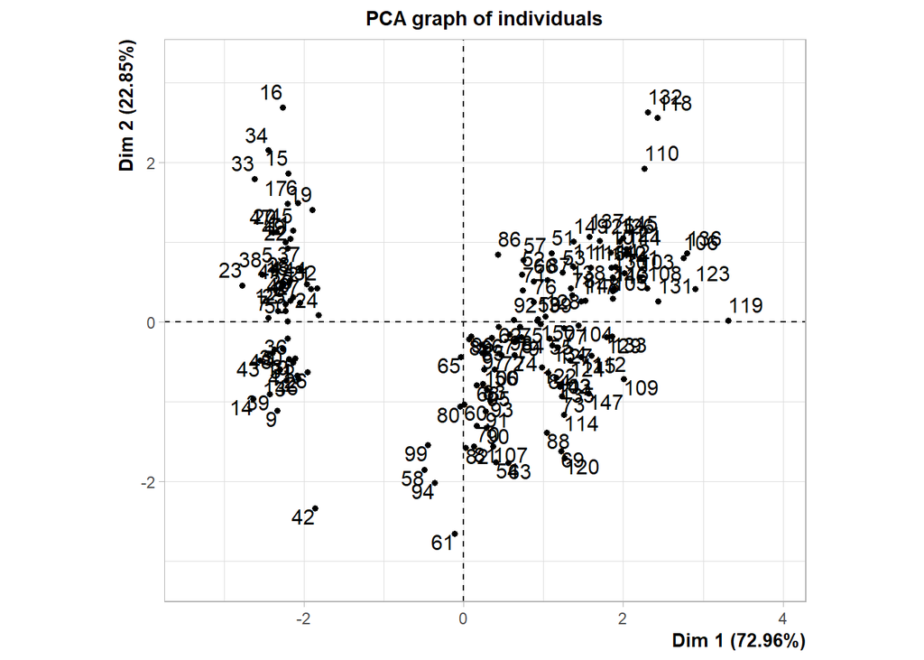

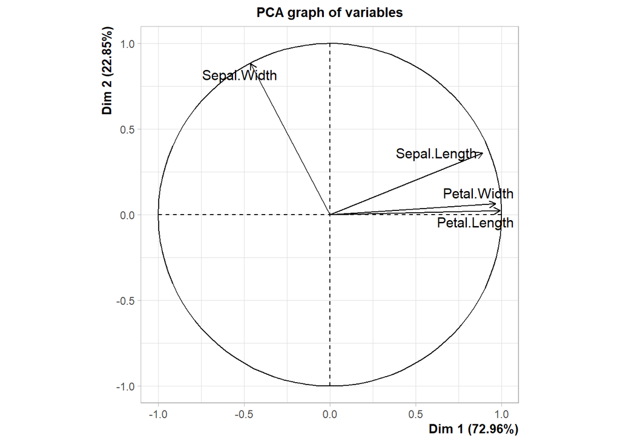

```r
pca_facto <- PCA(iris[,-5], graph = T) # call PCA {FactoMineR}
```

```r
pca_facto
```

```
## **Results for the Principal Component Analysis (PCA)**
## The analysis was performed on 150 individuals, described by 4 variables
## *The results are available in the following objects:
##
##    name               description
## 1  "$eig"             "eigenvalues"
## 2  "$var"             "results for the variables"
## 3  "$var$coord"       "coord. for the variables"
## 4  "$var$cor"         "correlations variables - dimensions"
## 5  "$var$cos2"        "cos2 for the variables"
## 6  "$var$contrib"     "contributions of the variables"
## 7  "$ind"             "results for the individuals"
## 8  "$ind$coord"       "coord. for the individuals"
## 9  "$ind$cos2"        "cos2 for the individuals"
## 10 "$ind$contrib"     "contributions of the individuals"
## 11 "$call"            "summary statistics"
## 12 "$call$centre"     "mean of the variables"
## 13 "$call$ecart.type" "standard error of the variables"
## 14 "$call$row.w"      "weights for the individuals"
## 15 "$call$col.w"      "weights for the variables"
```

### (a) first thing to check is the eigenvalues.

```r
eigenvalues <- pca_facto$eig # from above u can call any function
eigenvalues# 1st col is eigenvalues, 2nd is percentage (eigen*100),3rd is cummulative%
```

```
##        eigenvalue percentage of variance cumulative percentage of variance
## comp 1 2.91849782             72.9624454                          72.96245
## comp 2 0.91403047             22.8507618                          95.81321
## comp 3 0.14675688              3.6689219                          99.48213
## comp 4 0.02071484              0.5178709                         100.00000
```

#### **REMEMBER**: The amount of variation retained by each PC is called eigenvalues

#### (b) lets make Scee plot (as earlier)

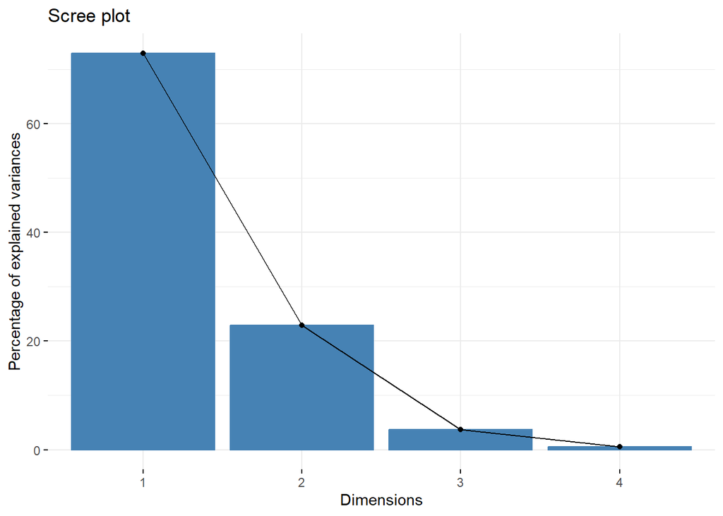

```r
fviz_screeplot(pca_facto)
```

#### OK, as earlier, eigen values around 1 or above is good to be selected, here in this example as seen, PC1 and 2 are 2.9 and 0.9. selecting only PC1 means that the component contains 72% (percentage of variance) of our variables. If we included the 2nd PC we can say confidently that 95% of the variables can be explained by both PC1 and 2 together [although eigenvalue is 0.9, i will selected].

#### (c) check the correlation between the variable and PC, this is called **loadings**

```r
pca_facto$var$coord
```

```
##                   Dim.1      Dim.2       Dim.3       Dim.4
## Sepal.Length  0.8901688 0.36082989 -0.27565767 -0.03760602
## Sepal.Width  -0.4601427 0.88271627  0.09361987  0.01777631
## Petal.Length  0.9915552 0.02341519  0.05444699  0.11534978
## Petal.Width   0.9649790 0.06399985  0.24298265 -0.07535950
```

#### **NOTE** the variables can be plotted (below) as a point in the component space using their loadings

#### (d) to see the loading (Contributions of the variables to the principal components)

```r
pca_facto$var$contrib
```

```
##                  Dim.1       Dim.2     Dim.3     Dim.4
## Sepal.Length 27.150969 14.24440565 51.777574  6.827052
## Sepal.Width   7.254804 85.24748749  5.972245  1.525463
## Petal.Length 33.687936  0.05998389  2.019990 64.232089
## Petal.Width  31.906291  0.44812296 40.230191 27.415396
```

#### (e)to see the Contributions of the individuals. I will show only the top 6 and last 6 hits to save space:))

```r
head(pca_facto$ind$contrib) # note that calling pca_facto will show these commands as shown ealier.
```

```
##       Dim.1      Dim.2       Dim.3       Dim.4
## 1 1.1715796 0.16806554 0.074085470 0.018798188
## 2 0.9891845 0.33146674 0.250034006 0.341474919
## 3 1.2768164 0.08526419 0.008875320 0.025915633
## 4 1.2077372 0.26029781 0.037858004 0.140000650
## 5 1.3046313 0.30516562 0.001125175 0.041530572
## 6 0.9841236 1.61748779 0.003303827 0.001405371
```

```r
tail(pca_facto$ind$contrib)
```

```
##         Dim.1        Dim.2       Dim.3      Dim.4
## 145 0.9120198 0.8028580333 1.816822334 1.47447779
## 146 0.7992200 0.1092179112 0.298345079 4.87640479
## 147 0.5591717 0.5864481607 0.003159185 1.56038116
## 148 0.5285732 0.0528050991 0.147474061 0.45705598
## 149 0.4304832 0.7458799467 3.957687038 0.02197157
## 150 0.2108071 0.0004318091 1.267614895 0.85589040
```

#### ** (d) and (e) values will be used later for drawing the loading plot

#### Cos2: checking quality of the representation for variables on the factor map

#### **The squared loadings for variables are called cos2**

#### The cos2 values are used to estimate the quality of the representation

#### The closer a variable is to the circle of correlations, the better its representation on the factor map (and the more important it is to interpret these components)

#### Variables that are closed to the center of the plot are less important for the first components.

```r
pca_facto$var$cos2
```

```
##                  Dim.1       Dim.2       Dim.3        Dim.4
## Sepal.Length 0.7924004 0.130198208 0.075987149 0.0014142127
## Sepal.Width  0.2117313 0.779188012 0.008764681 0.0003159971
## Petal.Length 0.9831817 0.000548271 0.002964475 0.0133055723
## Petal.Width  0.9311844 0.004095980 0.059040571 0.0056790544
```

#### For variables

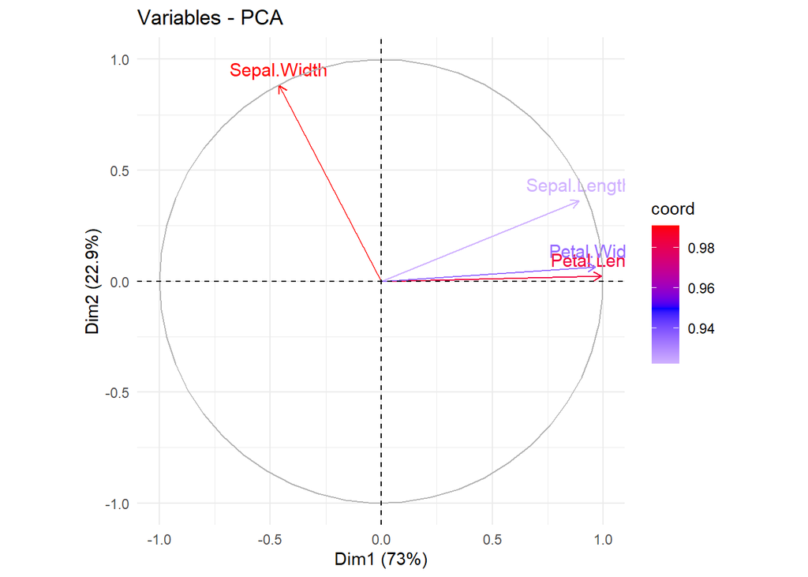

```r
fviz_pca_var(pca_facto, col.var="coord") + scale_color_gradient2(low="white", mid="blue", high="red",midpoint=0.95) + theme_minimal()
```

#### Lets look on the PC2 (the Y axis), have a look on the loadings of the PC2. all variables affects positively on the PC2. Thans why they are on the upper half of the graph. perhaps sepal width is the most contributor.

#### **NOTE** you may need to adjust the midpoint based on your values. also , u can adjust the color based on the variables loadings (coord) or cos2.

#### For individuals This loads the individual contributions (code e)

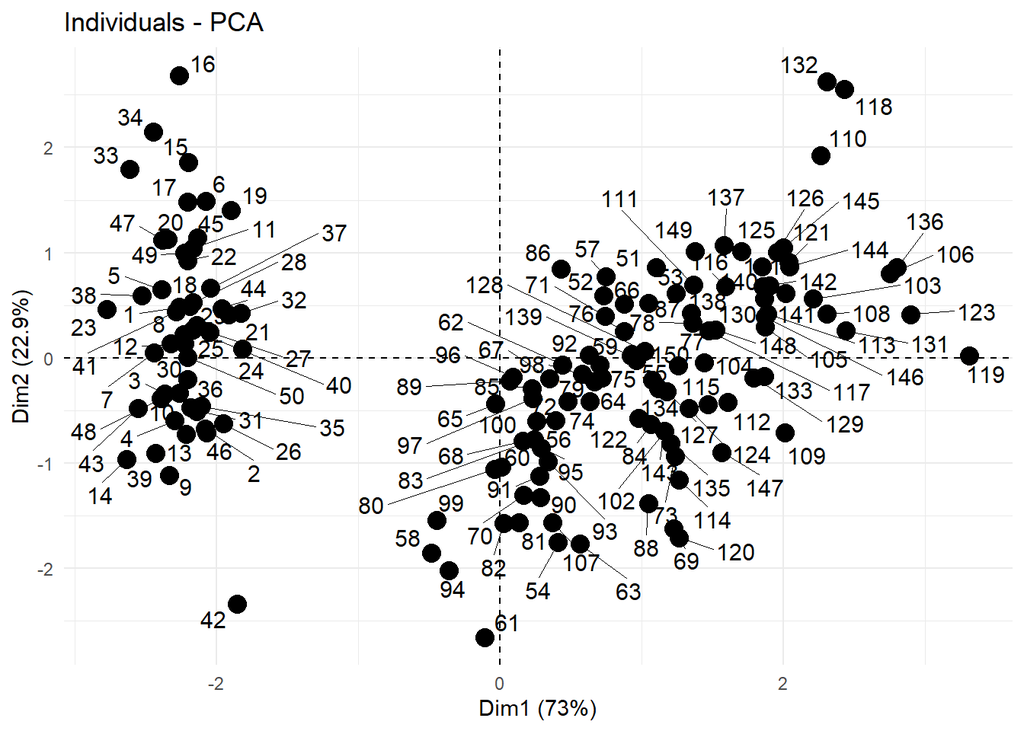

```r
fviz_pca_ind(pca_facto, col.var="cos2", pointsize=4, jitter = list(width = 0.3, height = 0.3))+scale_color_gradient2(midpoint=0.95) + theme_minimal()
```

#### Specifiying individuals based on color for groups

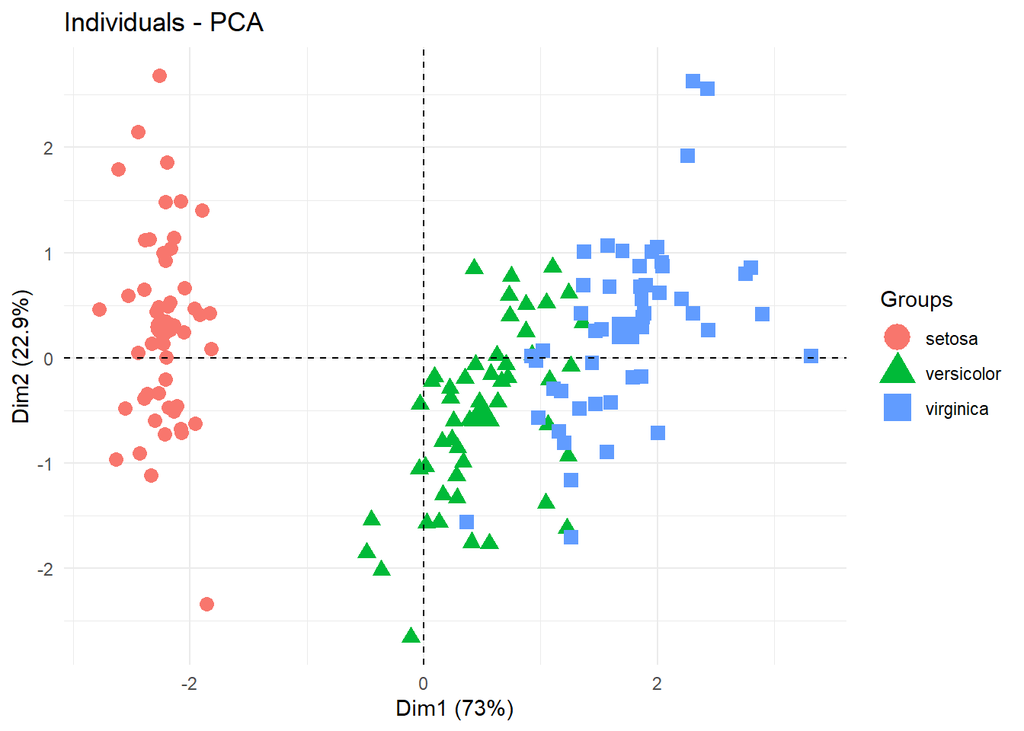

```r
fviz_pca_ind(pca_facto,geom="point",pointsize=3,habillage=iris$Species,jitter = list(width = 0.3, height = 0.3)) + theme_minimal()
```

#### Specifiying individuals based on color for groups with ellipses

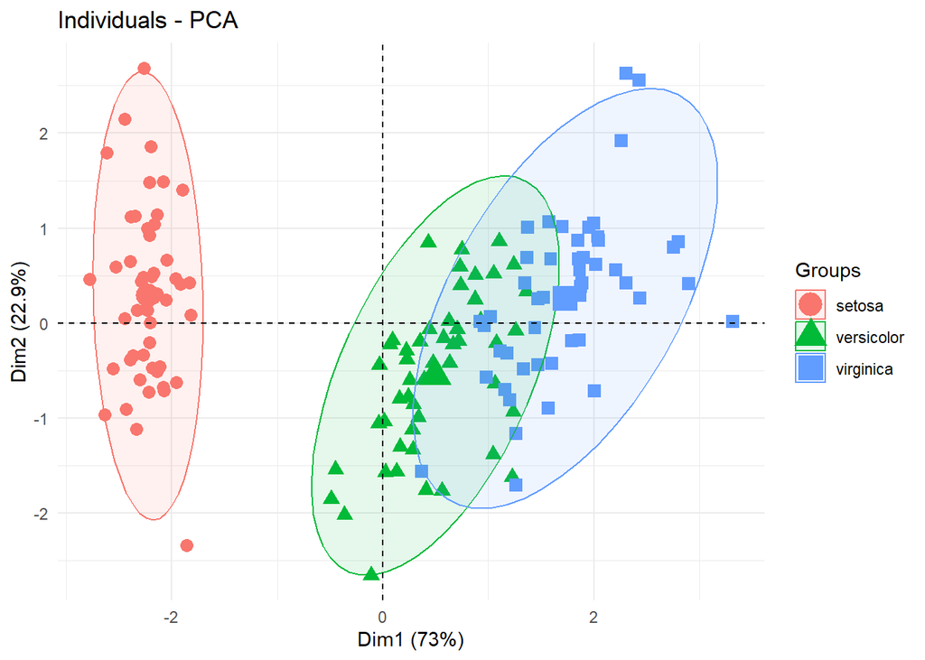

```r
fviz_pca_ind(pca_facto,geom="point",pointsize=3,habillage=iris$Species,jitter = list(width = 0.3, height = 0.3),addEllipses=TRUE,ellipse.level= 0.95)+ theme_minimal()
```

#### I can fairly say that setosa species differes that the other 2 versicolor and virginica. the last 2 seems to be little bit variant but in the same line.

#### Biplot including variables and individuals colored by group

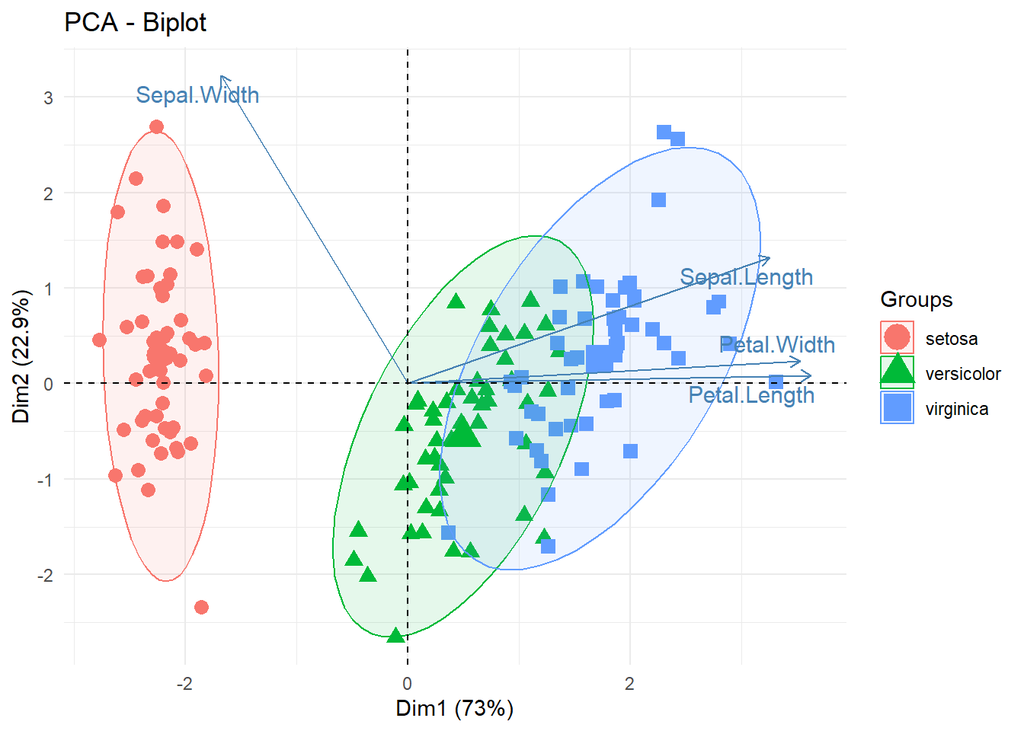

```r
fviz_pca_biplot(pca_facto,geom="point",pointsize=3,habillage=iris$Species,jitter = list(width = 0.3, height = 0.3),addEllipses=TRUE,ellipse.level= 0.95)+ theme_minimal()
```

#### color tweak with scale color brewer (needs loading of RColorBrewer)

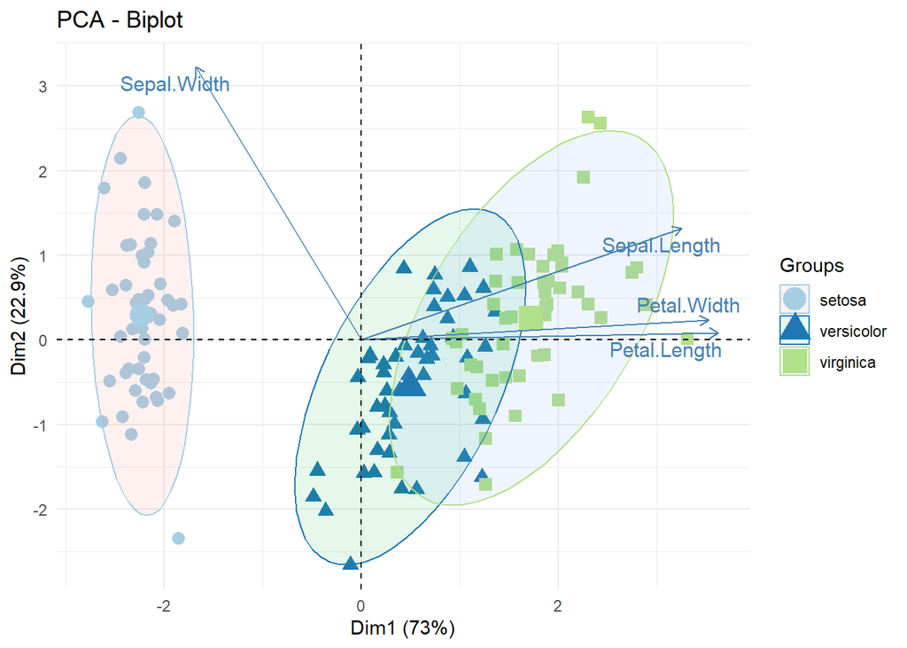

```r
fviz_pca_biplot(pca_facto, geom="point", pointsize=3, habillage=iris$Species, jitter = list(width = 0.3, height = 0.3), addEllipses=TRUE, ellipse.level= 0.95) + theme_minimal() + scale_color_brewer(palette="Paired")
```

#### Checking which is the most variable contribute on PC1

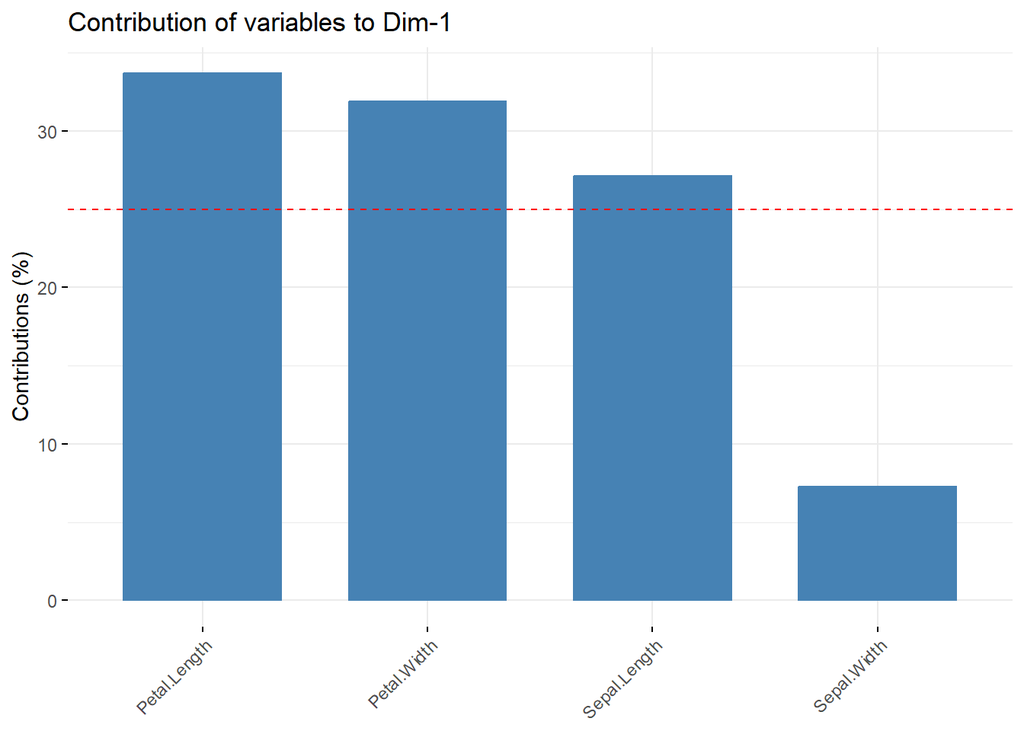

```r
fviz_contrib(pca_facto, choice = "var", axes = 1)
```

#### Checking which is the most variable contribute on PC2

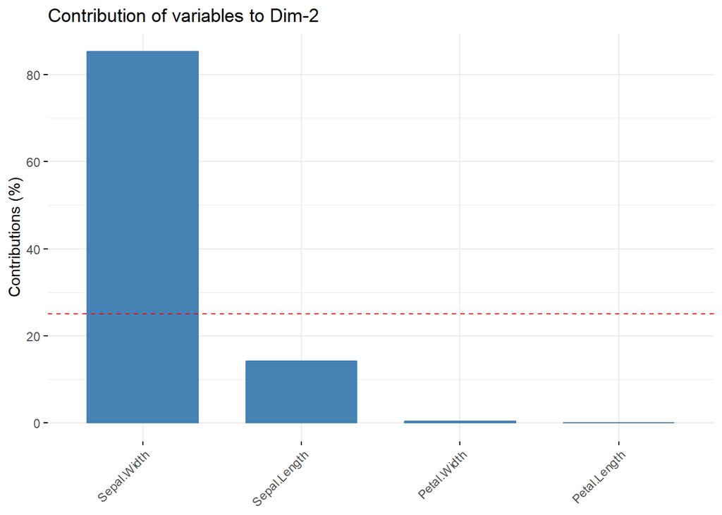

```r
fviz_contrib(pca_facto, choice = "var", axes = 2)
```

#### Checking which is the most variable contribute on both

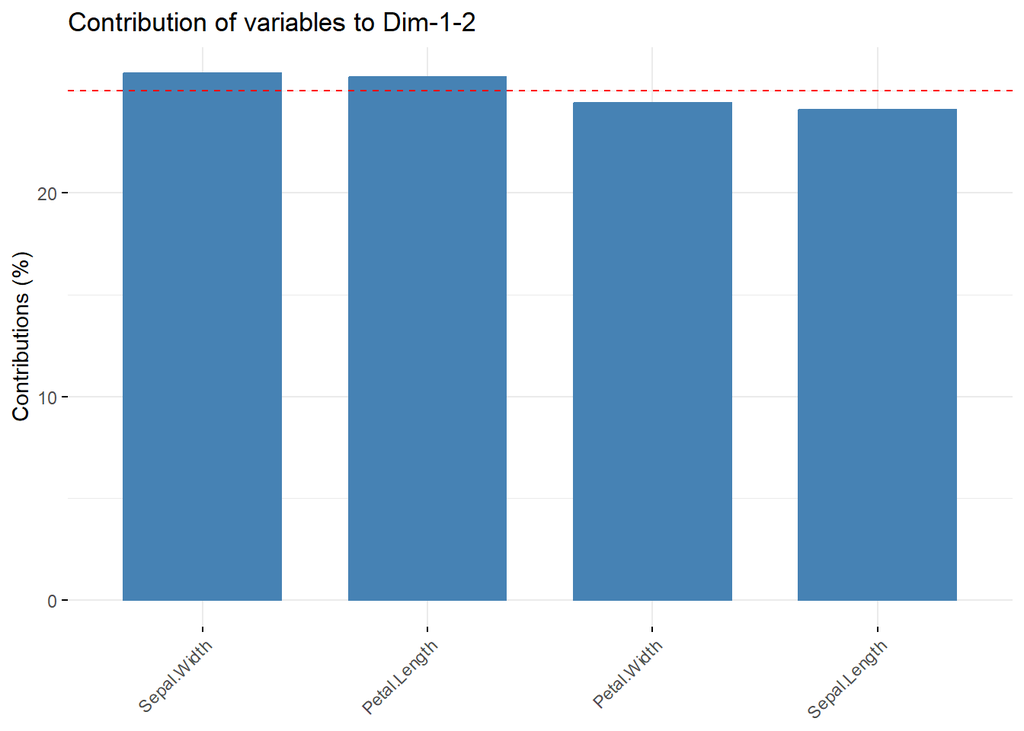

```r
fviz_contrib(pca_facto, choice = "var", axes = 1:2)
```

#### If you have more variables , you can set the top 3 or n

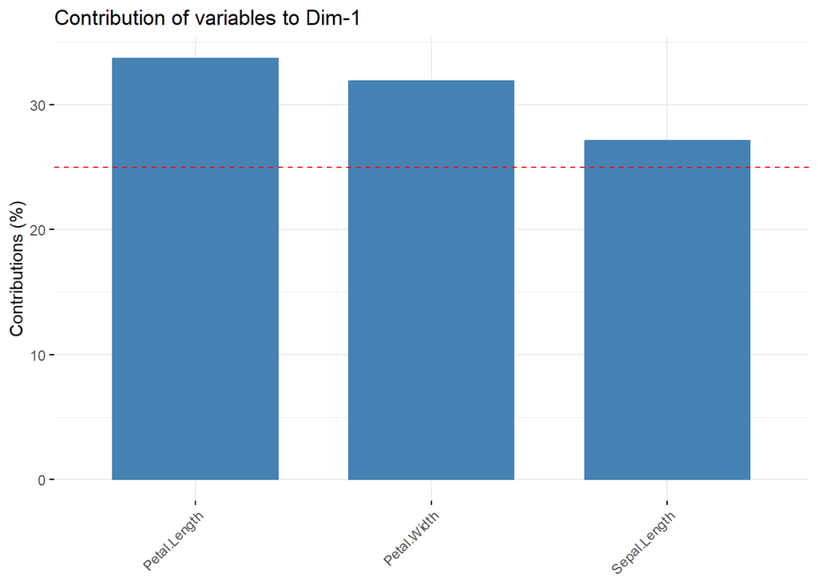

```r
fviz_contrib(pca_facto, choice = "var", axes = 1, top = 3)
```

#### Finally, I wonder how thes Iris flowers looks like

#### Iris, Setosa

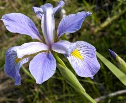

#### Iris, versicolor

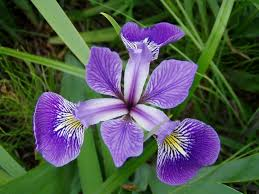

#### Iris, virginaca

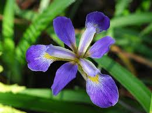

#### My Iris ??

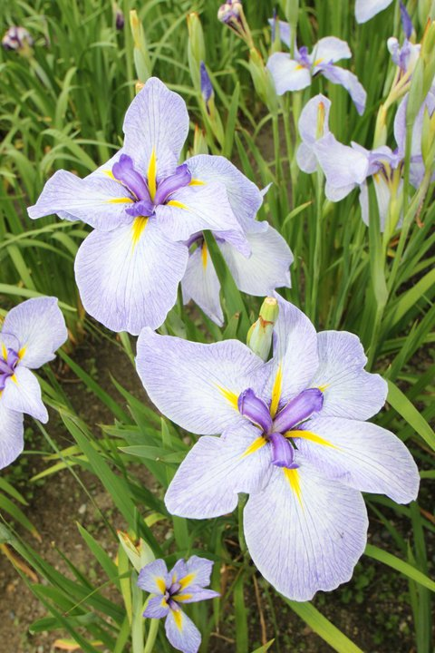

my graph

## Partial Least Squares (PLS)

> Partial Least Squares (PLS) offers a solution. It involves standardizing predictors and the response, then creating a smaller set of uncorrelated “PLS components” that capture substantial variance in both. These components are then used in a linear regression. Finally, k-fold cross-validation determines the ideal number of PLS components for the model.

### 1. Load Necessary Packages

```r
library(pls)
#view first six rows of mtcars dataset
head(mtcars)
```

```
##                    mpg cyl disp  hp drat    wt  qsec vs am gear carb
## Mazda RX4         21.0   6  160 110 3.90 2.620 16.46  0  1    4    4
## Mazda RX4 Wag     21.0   6  160 110 3.90 2.875 17.02  0  1    4    4
## Datsun 710        22.8   4  108  93 3.85 2.320 18.61  1  1    4    1
## Hornet 4 Drive    21.4   6  258 110 3.08 3.215 19.44  1  0    3    1
## Hornet Sportabout 18.7   8  360 175 3.15 3.440 17.02  0  0    3    2
## Valiant           18.1   6  225 105 2.76 3.460 20.22  1  0    3    1
```

### 2. Fit Partial Least Squares Model

```r
#make this example reproducible
set.seed(1)
#fit PCR model
model <- plsr(hp~mpg+disp+drat+wt+qsec, data=mtcars, scale=TRUE, validation="CV")
```

> scale=TRUE standardizes the predictor variables by centering them at zero mean and scaling to unit variance. This prevents variables measured on different scales from disproportionately influencing the model.

> validation=“CV” employs k-fold (default k=10) cross-validation to assess model performance. Alternatively, validation=“LOOCV” performs leave-one-out cross-validation.

### 3. Choose the Number of PLS Components

```r
#view summary of model fitting
summary(model)
```

```
## Data:    X dimension: 32 5
##  Y dimension: 32 1
## Fit method: kernelpls
## Number of components considered: 5
##
## VALIDATION: RMSEP
## Cross-validated using 10 random segments.
##        (Intercept)  1 comps  2 comps  3 comps  4 comps  5 comps
## CV           69.66    38.81    34.94    36.08    37.27    37.40
## adjCV        69.66    38.69    34.64    35.72    36.82    36.95
##
## TRAINING: % variance explained
##     1 comps  2 comps  3 comps  4 comps  5 comps
## X     68.66    89.27    95.82    97.94   100.00
## hp    71.84    81.74    82.00    82.02    82.03
```

#### Although additional components will always increase explained variance, the gain beyond two components is minimal.

#### The validationplot() function visualizes the test RMSE (along with MSE and R-squared) against the number of PLS components.

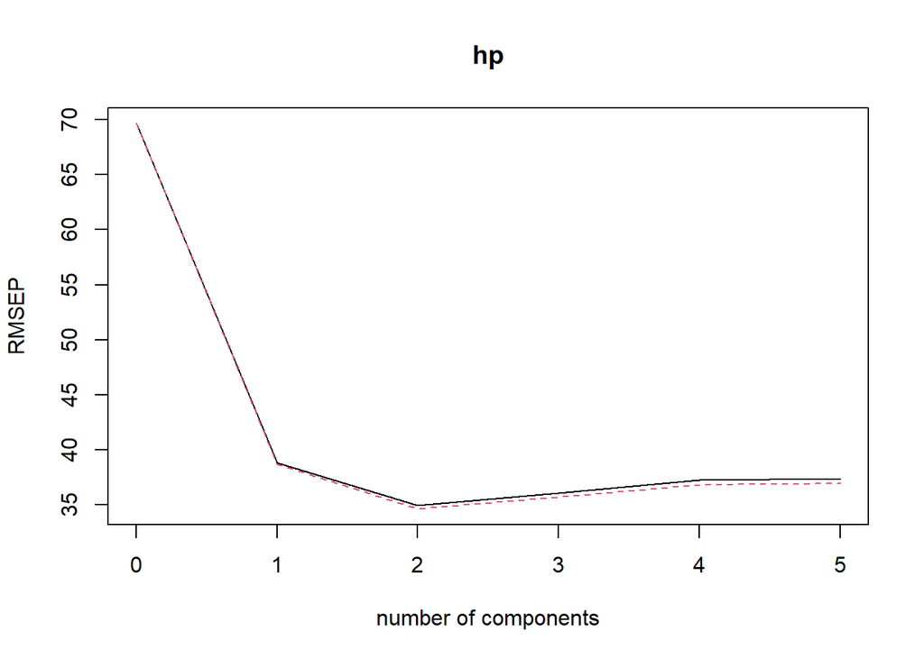

```r
#visualize cross-validation plots
validationplot(model)
```

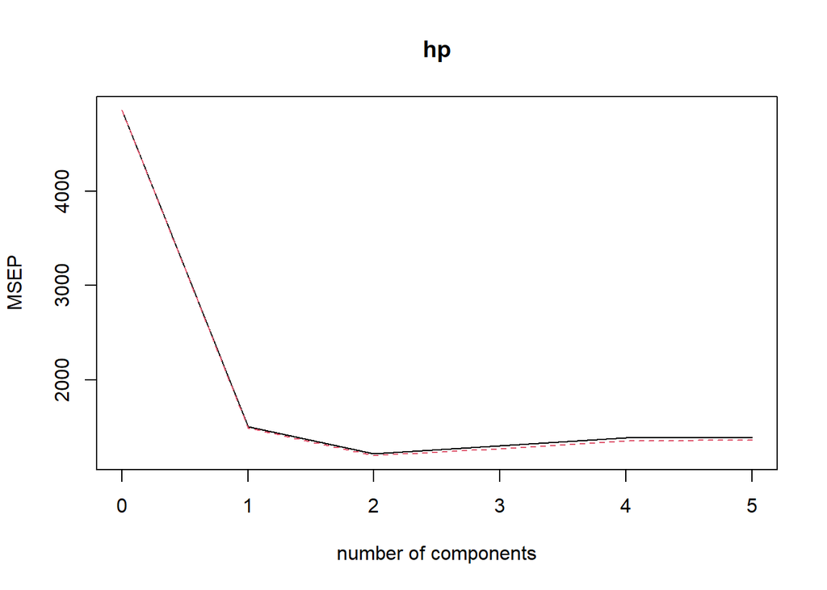

```r
validationplot(model, val.type="MSEP")
```

### 4. Use the Final Model to Make Predictions

#### To predict outcomes for new data, we can apply our final two-component PLS model. The code below demonstrates how to divide the original data into training and testing sets, then uses the trained two-component PLS model to generate predictions for the held-out test data.

```r
#define training and testing sets
train <- mtcars[1:25, c("hp", "mpg", "disp", "drat", "wt", "qsec")]
y_test <- mtcars[26:nrow(mtcars), c("hp")]
test <- mtcars[26:nrow(mtcars), c("mpg", "disp", "drat", "wt", "qsec")]

#use model to make predictions on a test set
model <- plsr(hp~mpg+disp+drat+wt+qsec, data=train, scale=TRUE, validation="CV")
pcr_pred <- predict(model, test, ncomp=2)

#calculate RMSE
sqrt(mean((pcr_pred - y_test)^2))
```

```
## [1] 54.89609
```

### Another Example

```r
library(pls)
library(MASS) # For USJudgeRatings

# Load the USJudgeRatings data
data(USJudgeRatings)

# Remove the first column (presumably judge names or IDs)
judge_ratings <- USJudgeRatings[, -1]

# Make the example reproducible
set.seed(1)

# Fit PLS model (using all other variables to predict RTEN - Retention)
model <- plsr(RTEN ~ ., data = judge_ratings, scale = TRUE, validation = "CV")

# View summary of model fitting
summary(model)
```

```
## Data:    X dimension: 43 10
##  Y dimension: 43 1
## Fit method: kernelpls
## Number of components considered: 10
##
## VALIDATION: RMSEP
## Cross-validated using 10 random segments.
##        (Intercept)  1 comps  2 comps  3 comps  4 comps  5 comps  6 comps
## CV           1.114   0.2052   0.1328   0.1224   0.1351   0.1317   0.1273
## adjCV        1.114   0.2048   0.1319   0.1218   0.1328   0.1300   0.1261
##        7 comps  8 comps  9 comps  10 comps
## CV      0.1311   0.1331   0.1335    0.1335
## adjCV   0.1293   0.1312   0.1316    0.1316
##
## TRAINING: % variance explained
##       1 comps  2 comps  3 comps  4 comps  5 comps  6 comps  7 comps  8 comps
## X       91.64    95.24    98.21    98.49    99.26    99.55    99.73    99.89
## RTEN    96.78    98.83    98.99    99.08    99.10    99.13    99.15    99.15
##       9 comps  10 comps
## X       99.95    100.00
## RTEN    99.15     99.15
```

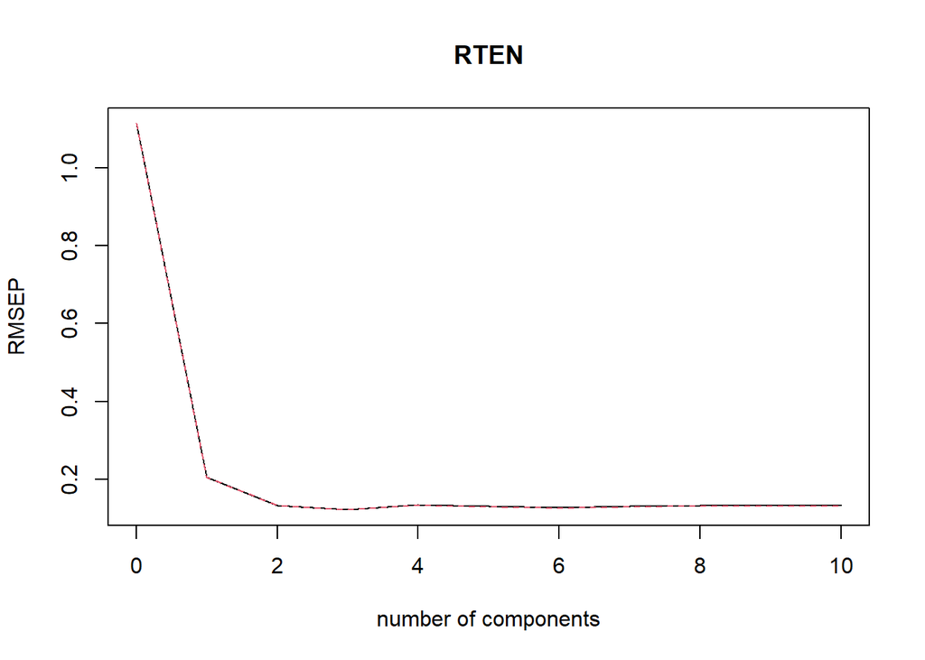

```r
# Visualize CV plots
validationplot(model)
```

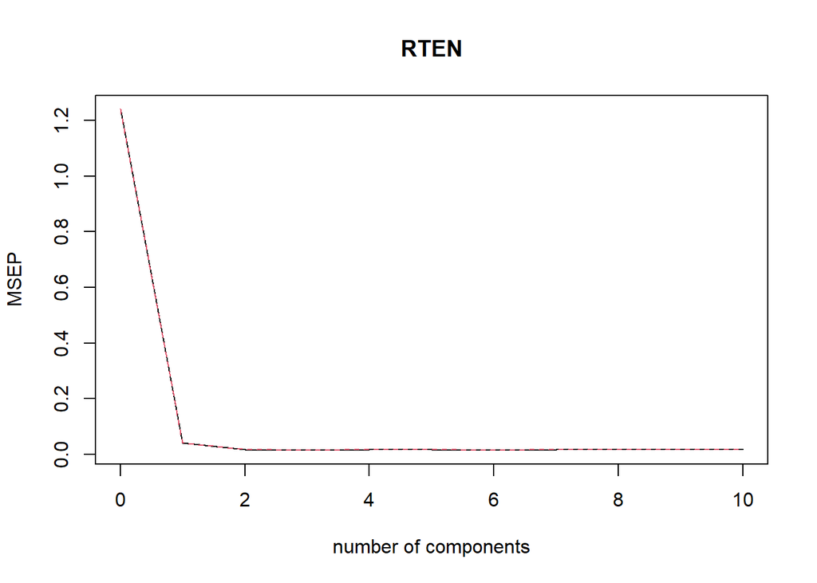

```r
validationplot(model, val.type = "MSEP")
```

```r
# Calculate CV R-squared (as explained in previous responses)
r_squared <- function(y, y_pred) {
  1 - sum((y - y_pred)^2) / sum((y - mean(y))^2)
}

# Define training and testing sets (70/30 split)
n <- nrow(judge_ratings)
train_index <- sample(1:n, 0.7 * n)
train <- judge_ratings[train_index, ]
test <- judge_ratings[-train_index, ]
y_test <- test$RTEN  # Separate the response variable from the test set

# Refit the model on the *training* data (using the same formula)
model <- plsr(RTEN ~ ., data = train, scale = TRUE, validation = "CV")

# Use the model to make predictions on the *test* set (using optimal ncomp)
pls_pred <- predict(model, newdata = test, ncomp = 1) # Predict using optimal ncomp

# Calculate RMSE on the *test* set
rmse_test <- sqrt(mean((pls_pred - y_test)^2))
print(paste("Test RMSE:", rmse_test))
```

```
## [1] "Test RMSE: 0.248402392611099"
```

```r
# Calculate R-squared on the *test* set
r_squared_test <- r_squared(y_test, pls_pred)
print(paste("Test R-squared:", r_squared_test))
```

```
## [1] "Test R-squared: 0.958194621862246"
```